# Bumblebee Lab 6

2/22/19

```r
knitr::opts_chunk$set(echo = FALSE)
```

# Bumblebee Lab 6

## Supporting Plots

## Conclusions

## Recommendation to DIA Managers

## Individual Plots

### William

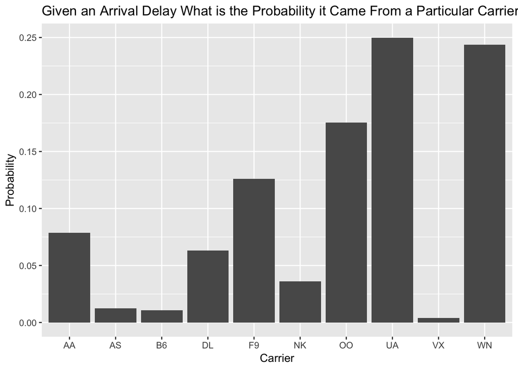

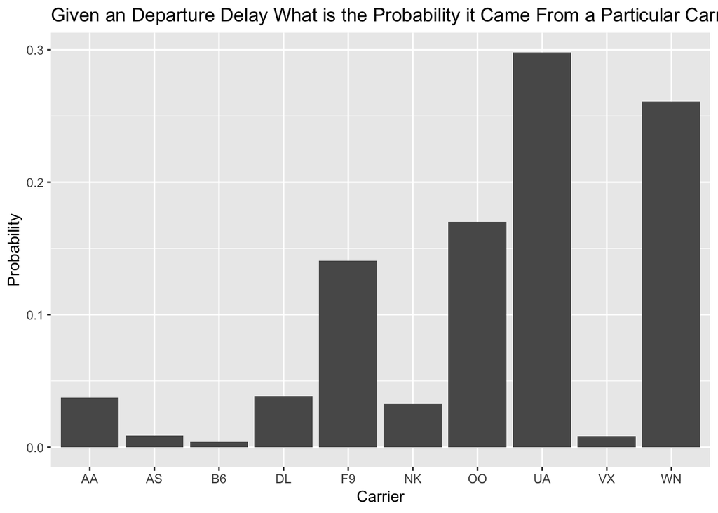

In this code, I divide the data into flight that depart from Denver and those that arrive in Denver in order to isolate the factors that lead to delays in the respective data sets. In the data frame titled OrgDen (flights that originate from Denver), I seek to look at the factors that contribute departure delays. In the data frame titles DestDen (flights whose destination is Denver), I seek to look at the factors that contribute to arrival delays. In my analysis, I look at the conditional probability that given a delay occured, the flight was from a particluar airline. In the cases of both departure delay and arrival, one can see that UA airline has the highest probability of being the airline given that a delay occurar. From this analysis, one can use these result to better understand which airlines contribute to delays in general within the Denver aiport.

### Brady

### Manasi

### Rachael

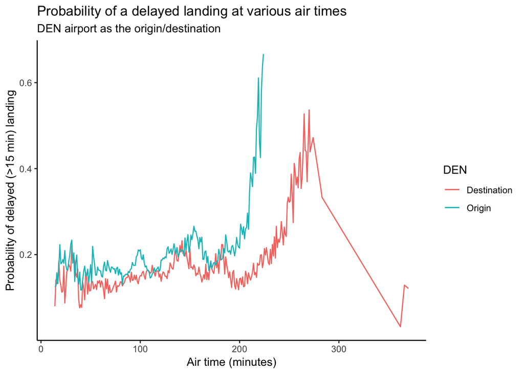

Finding #1- To manipulate this data I first looked at flights arriving to Denver (i.e. Destination DEN) and calculated the proportion of flights with delayed arrival, corresponding to their relative flight time. In order to rule out probabilistic outliers, I referenced the CLT and only calculated proportions of delayed arrival for air times with more than 30 data points. However, there are clearly still some high leverage points remaining. For flights not unusually long, the plot shows a positive trend between air time and probability of delayed arrival. From around 20 to 280 minutes, an increase in probability in demonstrated. This implies that a longer flight (while not unusually long) is more likely to arrive to DEN delayed.

Finding #2- I manipulated the data in a similar way to calculate the proportion of delayed arrivals where DEN is the origin airport. Outliers were regulated for in the same way as before. However, the positive trend is still the same. As air time increases, the probability of having a delayed arrival at a different airport increases. This implies that a longer flight (while not unusually long) is more likely to arrive at other airports from DEN, delayed.

## Individual contribution and non-defaults in plot generation

### William

### Brady

### Manasi

### Rachael